# Bayesian GLMM Part4

Author

Murray Logan

Published

09/09/2025

# 1 Preparations

Load the necessary libraries

```r
library(tidyverse) # for data wrangling
library(car) # for regression diagnostics
library(broom) # for tidy output
library(ggfortify) # for model diagnostics
library(knitr) # for kable
library(emmeans) # for estimating marginal means
library(MASS) # for glm.nb
library(brms)
library(broom.mixed)
library(tidybayes)
library(bayesplot)
library(standist) # for visualizing distributions
library(rstanarm)
library(cmdstanr) # for cmdstan
library(ggeffects)
library(rstan)
library(DHARMa)
library(ggridges)
library(easystats) # framework for stats, modelling and visualisation
library(patchwork)
library(modelsummary)
source("helperFunctions.R")
```

# 2 Scenario

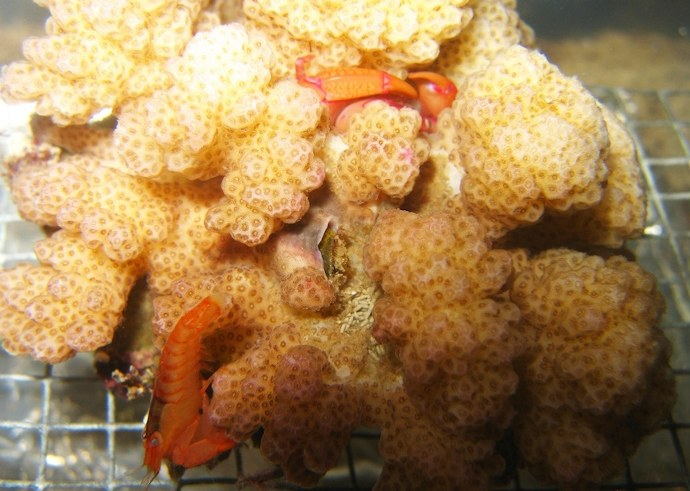

**Figure** 1: Crab_shrimp_coral

To investigate synergistic coral defence by mutualist crustaceans, Mckeon et al. (2012) conducted an aquaria experiment in which colonies of a coral species were placed in a tank along with a predatory sea star and one of four symbiont combinations:

- no symbiont,
- a crab symbiont
- a shrimp symbiont
- both a crab and shrimp symbiont.

The experiments were conducted in a large octagonal flow-through seawater tank that was partitioned into eight sections, which thereby permitted two of each of the four symbiont combinations to be observed concurrently. The tank was left overnight and in the morning, the presence of feeding scars on each coral colony was scored as evidence of predation. The experiments were repeated ten times, each time with fresh coral colonies, sea stars and symbiont.

The ten experimental times represent blocks (random effects) within which the symbiont type (fixed effect) are nested.

# 3 Read in the data

```r
mckeon <- read_csv("../data/mckeon.csv", trim_ws = TRUE)
```

**glimpse**

```r
glimpse(mckeon)
```

```
Rows: 80
Columns: 3
$ BLOCK     <dbl> 1, 1, 2, 2, 3, 3, 4, 4, 5, 5, 6, 6, 7, 7, 8, 8, 9, 9, 10, 10…
$ PREDATION <dbl> 0, 1, 1, 1, 1, 1, 1, 1, 1, 1, 1, 1, 1, 1, 1, 1, 1, 1, 1, 0, …
$ SYMBIONT  <chr> "none", "none", "none", "none", "none", "none", "none", "non…
```

**head**

```r
## Explore the first 6 rows of the data
head(mckeon)
```

```
# A tibble: 6 × 3
  BLOCK PREDATION SYMBIONT
  <dbl>     <dbl> <chr>
1     1         0 none
2     1         1 none
3     2         1 none
4     2         1 none
5     3         1 none
6     3         1 none
```

**str**

```r
str(mckeon)
```

```
spc_tbl_ [80 × 3] (S3: spec_tbl_df/tbl_df/tbl/data.frame)
 $ BLOCK    : num [1:80] 1 1 2 2 3 3 4 4 5 5 ...
 $ PREDATION: num [1:80] 0 1 1 1 1 1 1 1 1 1 ...
 $ SYMBIONT : chr [1:80] "none" "none" "none" "none" ...
 - attr(*, "spec")=
  .. cols(
  ..   BLOCK = col_double(),
  ..   PREDATION = col_double(),
  ..   SYMBIONT = col_character()
  .. )
 - attr(*, "problems")=<externalptr>
```

**Easystats (datawizard)**

```r
mckeon |> datawizard::data_codebook()
```

```
mckeon (80 rows and 3 variables, 3 shown)

ID | Name      | Type      | Missings |  Values |          N
---+-----------+-----------+----------+---------+-----------
1  | BLOCK     | numeric   | 0 (0.0%) | [1, 10] |         80
---+-----------+-----------+----------+---------+-----------
2  | PREDATION | numeric   | 0 (0.0%) |       0 | 30 (37.5%)
   |           |           |          |       1 | 50 (62.5%)
---+-----------+-----------+----------+---------+-----------
3  | SYMBIONT  | character | 0 (0.0%) |    both | 20 (25.0%)
   |           |           |          |   crabs | 20 (25.0%)
   |           |           |          |    none | 20 (25.0%)
   |           |           |          |  shrimp | 20 (25.0%)
------------------------------------------------------------
```

Since the response here is the presence or absence of predation (feeding scars), a binomial distribution is appropriate.

We need to make sure that the categorical variable and the random effect are defined as factors. When doing so, it might be valuable to rearrange the order of the fixed effect (SYMBIONT) such that the `none` group is considered the first group. This way, the other levels will all naturally be compared to this level (hence it will be treated as a reference of control group).

```r
mckeon <- mckeon |>
  mutate(
    BLOCK = factor(BLOCK),
    SYMBIONT = factor(SYMBIONT, levels = c("none", "crabs", "shrimp", "both"))
  )
```

# 4 Exploratory data analysis

Random intercepts model formula:
$$\begin{align}
y_i &\sim{} \mathcal{N}(n, p_i)\\
ln\left(\frac{p_i}{1-p_1}\right) &=\boldsymbol{\beta} \bf{X_i} + \boldsymbol{\gamma} \bf{Z_i}\\
\beta_0 &\sim{} \mathcal{N}(0, 2.5)\\
\beta_1 &\sim{} \mathcal{N}(0, 3)\\
\boldsymbol{\gamma_j} &\sim{} \mathcal{N}(0, \sigma^2_b)\\
\sigma^2_b &\sim{} t(3, 0, 1.5)\\
\end{align}$$

where $\boldsymbol{\beta}$ and $\boldsymbol{\gamma}$ are vectors of the fixed and random effects parameters respectively and $\bf{X}$ is the model matrix representing the overall intercept and effects of symbionts on the probability of the colony experiencing predation. $\bf{Z}$ represents a cell means model matrix for the random intercepts associated with individual coral colonies.

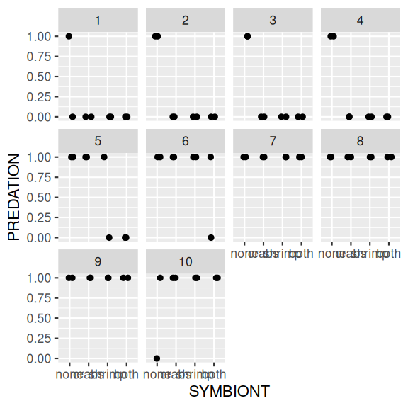

```r
ggplot(mckeon, aes(y = PREDATION, x = SYMBIONT)) +
  geom_point(position = position_jitter(width = 0.2, height = 0)) +
  facet_wrap(~BLOCK)
```

# 5 Fit the model

**rstanarm**

**Using default priors**

In `rstanarm`, the default priors are designed to be weakly informative. They are chosen to provide moderate regularisation (to help prevent over-fitting) and help stabilise the computations.

```r
mckeon_rstanarm <- stan_glmer(PREDATION ~ SYMBIONT + (1 | BLOCK),
  data = mckeon,
  family = binomial(link = "logit"),
  iter = 5000,
  warmup = 2000,
  chains = 3,
  thin = 5,
  refresh = 0,
  cores = 3
)
```

```r
mckeon_rstanarm %>% prior_summary()
```

```
Priors for model '.'
------
Intercept (after predictors centered)
 ~ normal(location = 0, scale = 2.5)

Coefficients
  Specified prior:
    ~ normal(location = [0,0,0], scale = [2.5,2.5,2.5])
  Adjusted prior:
    ~ normal(location = [0,0,0], scale = [5.74,5.74,5.74])

Covariance
 ~ decov(reg. = 1, conc. = 1, shape = 1, scale = 1)
------
See help('prior_summary.stanreg') for more details
```

This tells us:

- for the intercept (when the family is binomial), a normal prior with a mean of 0 and a standard deviation of 2.5 is used. These are the default priors for bernoulli models. A mean of 0 on a logit scale corresponds to a probability of 0.5. Hence the prior expected value is 0.5.
- for the coefficients (in this case, just the slope), the default prior is a normal prior centred around 0 with a standard deviation of 2.5. For binomial models, this is then adjusted for the scale of the data by dividing the 2.5 by the standard deviation of the predictor (then rounded).

```r
model.matrix(~SYMBIONT, data = mckeon) %>%
  apply(2, sd) %>%
  (function(x) 2.5 / x)
```

```
   (Intercept)  SYMBIONTcrabs SYMBIONTshrimp   SYMBIONTboth
           Inf       5.737305       5.737305       5.737305
```

**Assessing priors**

Lets now run with priors only so that we can explore the range of values they allow in the posteriors.

```r
mckeon_rstanarm1 <- update(mckeon_rstanarm, prior_PD = TRUE)
```

```
You are calculating adjusted predictions on the population-level (i.e.
  `type = "fixed"`) for a *generalized* linear mixed model.
  This may produce biased estimates due to Jensen's inequality. Consider
  setting `bias_correction = TRUE` to correct for this bias.
  See also the documentation of the `bias_correction` argument.
```

```
Note: uncertainty of error terms are not taken into account. Consider
  setting `interval` to "prediction". This will call `posterior_predict()`
  instead of `posterior_epred()`.
```

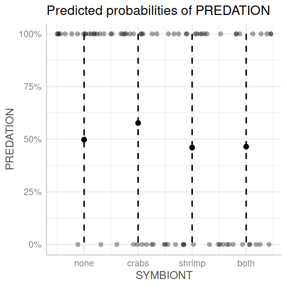

```r
mckeon_rstanarm1 %>%
  ggpredict() %>%
  plot(show_data = TRUE, jitter = c(0.5, 0))
```

**Conclusions:**

- it is very difficult to assess the priors from the predicted posteriors when the posteriors are on the response scale as they will always approach values of 0 and 1 (no matter how wide they are on the link scale).

Interestingly, if we instead use `ggemmeans`, it will (perhaps erroneously) generate the partial effects on the link scale (yet with an incorrectly labelled y-axis). Probability scale values of 0.99 and 0.01 (very large and small respectively) correspond to value of approximately 4.6 and -4.6 respectively on the logit scale.

In the following partial plot, the routine attempts to convert the y-axes tick marks into percentages. Hence a value of 0.1 is converted to 10%. Consequently, values of -5 and 5 are labelled as -500% and 500% respectively. We know that on the probability scale, values must asymptote towards 0 and 1. Posterior intervals beyond -5 and 5 might be considered wide.

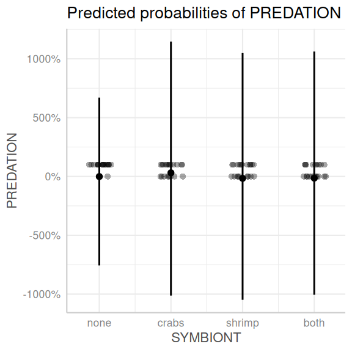

```r
mckeon_rstanarm1 %>%
  ggemmeans(~SYMBIONT) %>%
  plot(show_data = TRUE, jitter = c(0.5, 0))
```

Alternatively, we could create the plot ourselves…

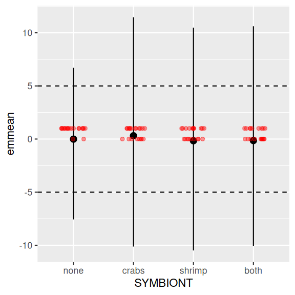

```r
mckeon_rstanarm1 %>%
  emmeans(~SYMBIONT, type = "link") %>%
  as.data.frame() %>%
  ggplot(aes(y = emmean, x = SYMBIONT)) +
  geom_hline(yintercept = c(5, -5), linetype = "dashed") +
  geom_pointrange(aes(ymin = lower.HPD, ymax = upper.HPD)) +
  geom_point(
    data = mckeon, aes(y = PREDATION),
    position = position_jitter(width = 0.2, height = 0),
    alpha = 0.4, color = "red"
  )
```

**Defining priors**

The following link provides some guidance about defining priors. [https://github.com/stan-dev/stan/wiki/Prior-Choice-Recommendations]

When defining our own priors, we typically do not want them to be scaled.

If we wanted to define our own priors that were less vague, yet still not likely to bias the outcomes, we could try the following priors (mainly plucked out of thin air):

I will also overlay the raw data for comparison.

```r
mckeon_rstanarm2 <- stan_glmer(PREDATION ~ SYMBIONT + (1 | BLOCK),
  data = mckeon,
  family = binomial(link = "logit"),
  prior_intercept = normal(0, 2.5, autoscale = FALSE),
  prior = normal(0, 6, autoscale = FALSE),
  prior_covariance = decov(1, 1, 1, 1),
  prior_PD = TRUE,
  iter = 5000,
  warmup = 1000,
  chains = 3,
  thin = 5,
  refresh = 0
)
```

```
Note: uncertainty of error terms are not taken into account. Consider
  setting `interval` to "prediction". This will call `posterior_predict()`
  instead of `posterior_epred()`.
```

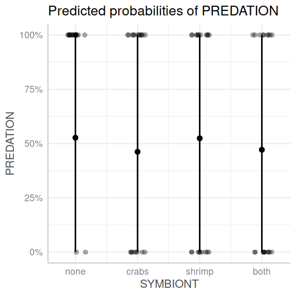

```r
mckeon_rstanarm2 %>%
  ggpredict(~SYMBIONT) %>%
  plot(show_data = TRUE, jitter = c(0.5, 0))
```

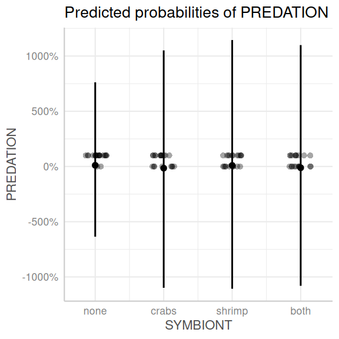

```r
mckeon_rstanarm2 %>%
  ggemmeans(~SYMBIONT) %>%
  plot(show_data = TRUE, jitter = c(0.5, 0))
```

Now lets refit, conditioning on the data.

```r
mckeon_rstanarm3 <- update(mckeon_rstanarm2, prior_PD = FALSE)
```

**Plotting prior and posterior**

```
Drawing from prior...
```

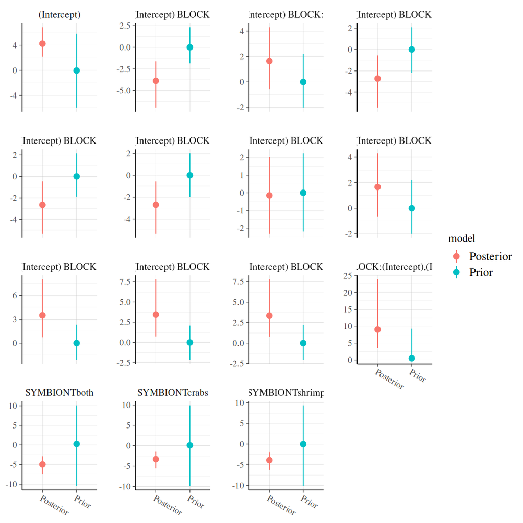

```r
posterior_vs_prior(mckeon_rstanarm3,
  color_by = "vs", group_by = TRUE,
  facet_args = list(scales = "free_y")
)
```

```
Data points may overlap. Use the `jitter` argument to add some amount of
  random variation to the location of data points and avoid overplotting.
```

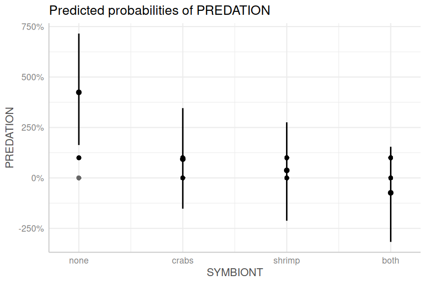

```r
ggemmeans(mckeon_rstanarm3, ~SYMBIONT) %>% plot(show_data = TRUE)
```

```
Note: uncertainty of error terms are not taken into account. Consider
  setting `interval` to "prediction". This will call `posterior_predict()`
  instead of `posterior_epred()`.
Data points may overlap. Use the `jitter` argument to add some amount of
  random variation to the location of data points and avoid overplotting.
```

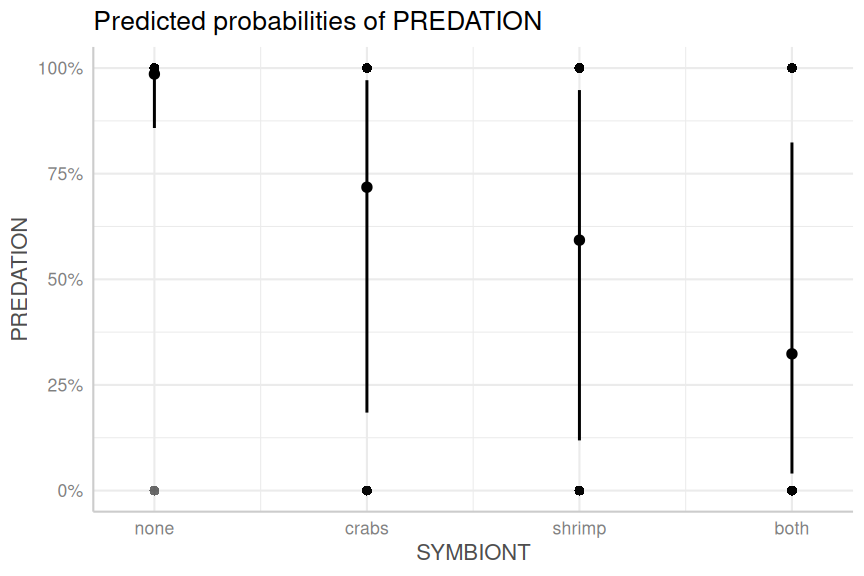

```r
ggpredict(mckeon_rstanarm3, ~SYMBIONT) %>% plot(show_data = TRUE)
```

**brms**

**Using default priors**

In `brms`, the default priors are designed to be weakly informative. They are chosen to provide moderate regularisation (to help prevent over fitting) and help stabilise the computations.

Unlike `rstanarm`, `brms` models must be compiled before they start sampling. For most models, the compilation of the stan code takes around 45 seconds.

```r
mckeon_form <- bf(PREDATION | trials(1) ~ SYMBIONT + (1|BLOCK),
                  family=binomial(link='logit'))
#OR
mckeon_form <- bf(PREDATION ~ SYMBIONT + (1|BLOCK),
                  family=bernoulli(link='logit'))
options(width=150)
mckeon_form |> get_prior(data = mckeon)
```

```
                prior     class           coef group resp dpar nlpar lb ub       source
               (flat)         b                                                 default
               (flat)         b   SYMBIONTboth                             (vectorized)
               (flat)         b  SYMBIONTcrabs                             (vectorized)
               (flat)         b SYMBIONTshrimp                             (vectorized)
 student_t(3, 0, 2.5) Intercept                                                 default
 student_t(3, 0, 2.5)        sd                                       0         default
 student_t(3, 0, 2.5)        sd                BLOCK                  0    (vectorized)
 student_t(3, 0, 2.5)        sd      Intercept BLOCK                  0    (vectorized)
```

```r
options(width=80)
```

**Defining priors**

The following link provides some guidance about defining priors. [https://github.com/stan-dev/stan/wiki/Prior-Choice-Recommendations]

When defining our own priors, we typically do not want them to be scaled.

If we wanted to define our own priors that were less vague, yet still not likely to bias the outcomes, we could try the following priors (mainly plucked out of thin air):

- $\beta_0$: normal centred at 0 (since this is 0.5 on the logit scale) with a standard deviation of 2.5
  - mean of 0: since `logit(0.5)`
  - sd of 2: since this not too large on logit scale
  - alternatively, we could potentially use `logistic(0,1)`
- $\beta_1$: normal centred at 0 with a standard deviation of 6
  - sd of 6: since `2.5/model.matrix(~SYMBIONT, data=mckeon) %>% apply(2,sd)`
- $\sigma_j$: half-cauchy with parameters 0 and 2.
- $\Sigma$: decov with:
  - regularisation: the exponent for a LKJ prior on the correlation matrix. A value of 1 (default) implies a joint uniform prior
  - concentration: the concentration parameter for a symmetric Dirichlet distribution. A value of 1 (default) implies a joint uniform distribution
  - shape and scale: the shape and scale parameters for a gamma prior on the scale and scale parameters of the decov prior. A value of 1 for both (default) simplifies the gamma prior to a unit-exponential distribution.

Note, for hierarchical models, the model will tend to want to have a large $sigma$ in order to fit the data better. It is a good idea to **regularise** this tendency by applying a prior that has most mass around zero. Suitable candidates include:

- half-t: as the degrees of freedom approach infinity, this will approach a half-normal
- half-cauchy: this is essentially a half-t with 1 degree of freedom
- exponential

I will also overlay the raw data for comparison.

```r
mckeon_form <- bf(PREDATION | trials(1) ~ SYMBIONT + (1 | BLOCK),
  family = binomial(link = "logit")
)
# OR
mckeon_form <- bf(PREDATION ~ SYMBIONT + (1 | BLOCK),
  family = bernoulli(link = "logit")
)
options(width = 150)
mckeon_form |> get_prior(data = mckeon)
```

```
                prior     class           coef group resp dpar nlpar lb ub       source
               (flat)         b                                                 default
               (flat)         b   SYMBIONTboth                             (vectorized)
               (flat)         b  SYMBIONTcrabs                             (vectorized)
               (flat)         b SYMBIONTshrimp                             (vectorized)
 student_t(3, 0, 2.5) Intercept                                                 default
 student_t(3, 0, 2.5)        sd                                       0         default
 student_t(3, 0, 2.5)        sd                BLOCK                  0    (vectorized)
 student_t(3, 0, 2.5)        sd      Intercept BLOCK                  0    (vectorized)
```

```r
options(width = 80)

mckeon |>
  group_by(SYMBIONT) |>
  summarise(
    Mean = logit(mean(PREDATION)),
    Median = logit(median(PREDATION)),
    sd = logit(abs(sd(PREDATION)))
  )
```

```
# A tibble: 4 × 4
  SYMBIONT   Mean Median      sd
  <fct>     <dbl>  <dbl>   <dbl>
1 none      2.20     Inf -0.810
2 crabs     0.405    Inf  0.0105
3 shrimp    0.201    Inf  0.0417
4 both     -0.201   -Inf  0.0417
```

```r
2.5 / model.matrix(~SYMBIONT, data = mckeon) |> apply(2, sd)
```

```
   (Intercept)  SYMBIONTcrabs SYMBIONTshrimp   SYMBIONTboth
           Inf       5.737305       5.737305       5.737305
```

```r
mckeon |>
  group_by(SYMBIONT) |>
  summarise(
    mean_response = mean(PREDATION),
    mad_response = mad(PREDATION),
    sd_response = sd(PREDATION),
  ) |>
  mutate(
    mean_logit = logit(mean_response),
    # Delta method approximation
    sd_logit = sd_response / (mean_response * (1 - mean_response))
  )
```

```
# A tibble: 4 × 6
  SYMBIONT mean_response mad_response sd_response mean_logit sd_logit
  <fct>            <dbl>        <dbl>       <dbl>      <dbl>    <dbl>
1 none              0.9             0       0.308      2.20      3.42
2 crabs             0.6             0       0.503      0.405     2.09
3 shrimp            0.55            0       0.510      0.201     2.06
4 both              0.45            0       0.510     -0.201     2.06
```

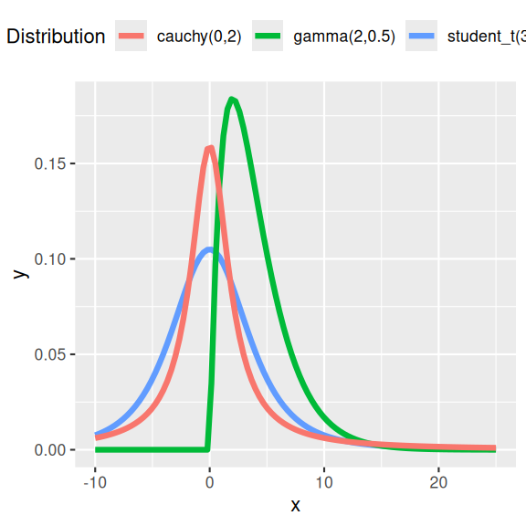

```r
standist::visualize("student_t(3, 0, 3.5)",
  "gamma(2,0.5)",
  "cauchy(0,2)",
  xlim = c(-10, 25)
)
```

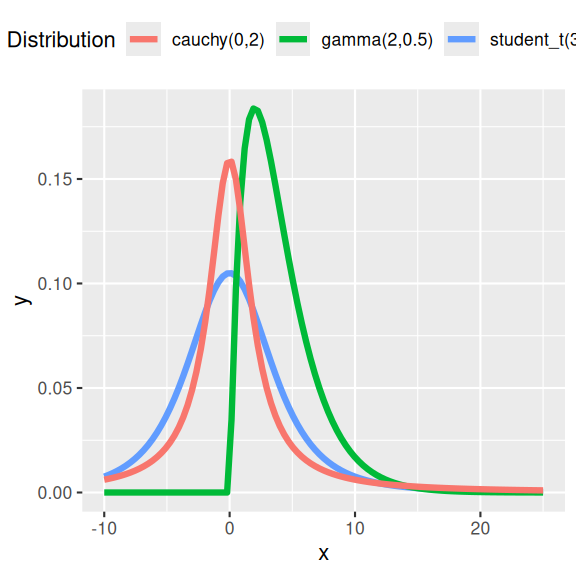

```r
standist::visualize("student_t(3, 0, 3.5)",
  "gamma(2,0.5)",
  "cauchy(0,2)",
  xlim = c(-10, 25)
)
```

```r
mckeon_form <- bf(PREDATION | trials(1) ~ SYMBIONT + (1 | BLOCK),
  family = binomial(link = "logit")
)
# OR
mckeon_form <- bf(PREDATION ~ SYMBIONT + (1 | BLOCK),
  family = bernoulli(link = "logit")
)
get_prior(mckeon_form, data = mckeon)
```

```
                prior     class           coef group resp dpar nlpar lb ub
               (flat)         b
               (flat)         b   SYMBIONTboth
               (flat)         b  SYMBIONTcrabs
               (flat)         b SYMBIONTshrimp
 student_t(3, 0, 2.5) Intercept
 student_t(3, 0, 2.5)        sd                                       0
 student_t(3, 0, 2.5)        sd                BLOCK                  0
 student_t(3, 0, 2.5)        sd      Intercept BLOCK                  0
       source
      default
 (vectorized)
 (vectorized)
 (vectorized)
      default
      default
 (vectorized)
 (vectorized)
```

```r
priors <-
  prior(normal(0, 2.5), class = "Intercept") +
  prior(normal(0, 3), class = "b") +
  prior(student_t(3, 0, 1.5), class = "sd")
priors <-
  prior(normal(0, 2), class = "Intercept") +
  prior(normal(0, 3), class = "b") +
  prior(student_t(3, 0, 1.5), class = "sd")

mckeon_brm2 <- brm(mckeon_form,
  data = mckeon,
  prior = priors,
  sample_prior = "only",
  iter = 5000,
  warmup = 1000,
  chains = 3, cores = 3,
  thin = 5,
  control = list(adapt_delta = 0.99, max_treedepth = 20),
  refresh = 0,
  backend = "rstan"
)
```

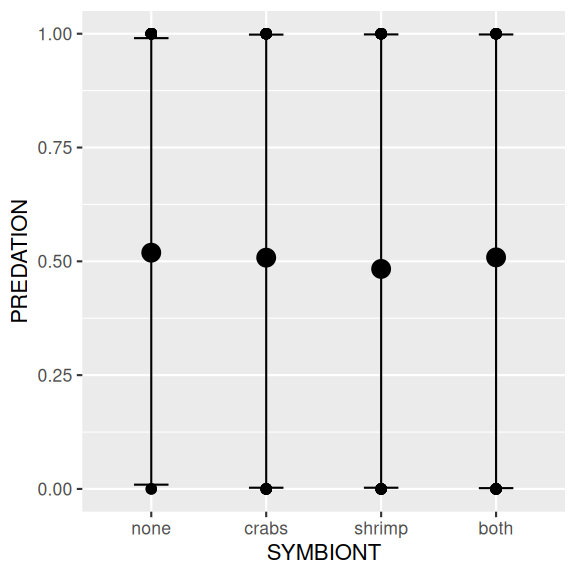

```r
mckeon_brm2 |>
  conditional_effects() |>
  plot(points = TRUE)
```

```
Note: uncertainty of error terms are not taken into account. Consider
  setting `interval` to "prediction". This will call `posterior_predict()`
  instead of `posterior_epred()`.
```

```
Data points may overlap. Use the `jitter` argument to add some amount of
  random variation to the location of data points and avoid overplotting.
```

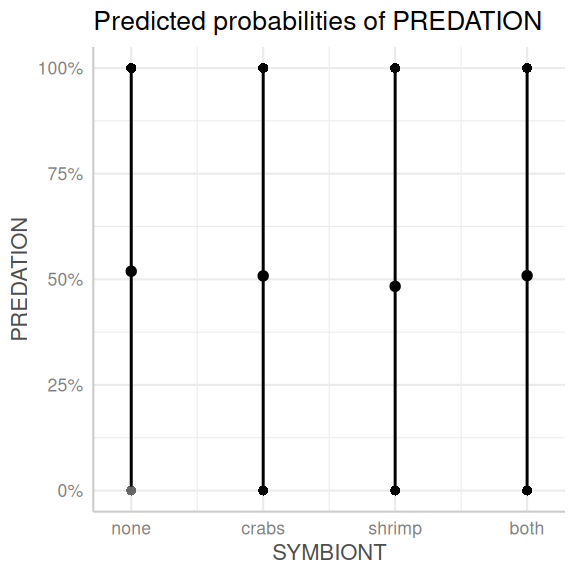

```r
mckeon_brm2 |>
  ggpredict(~SYMBIONT) |>
  plot(show_data = TRUE)
```

```
Data points may overlap. Use the `jitter` argument to add some amount of
  random variation to the location of data points and avoid overplotting.
```

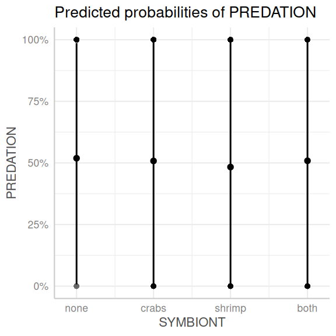

```r
mckeon_brm2 |>
  ggemmeans(~SYMBIONT) |>
  plot(show_data = TRUE)
```

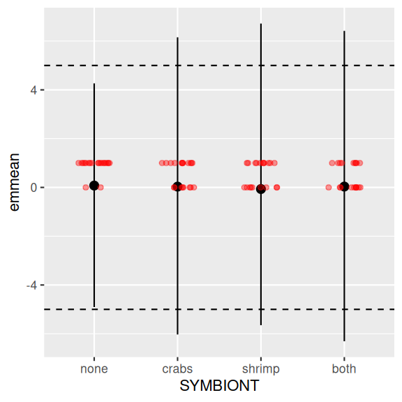

```r
mckeon_brm2 |>
  emmeans(~SYMBIONT, type = "link") |>
  as.data.frame() |>
  ggplot(aes(y = emmean, x = SYMBIONT)) +
  geom_hline(yintercept = c(5, -5), linetype = "dashed") +
  geom_pointrange(aes(ymin = lower.HPD, ymax = upper.HPD)) +
  geom_point(
    data = mckeon, aes(y = PREDATION),
    position = position_jitter(width = 0.2, height = 0),
    alpha = 0.4, color = "red"
  )
```

Now lets refit, conditioning on the data.

```r
mckeon_brm3 <- update(mckeon_brm2,
  sample_prior = "yes",
  cores = 3,
  refresh = 0
)
```

```
The desired updates require recompiling the model
```

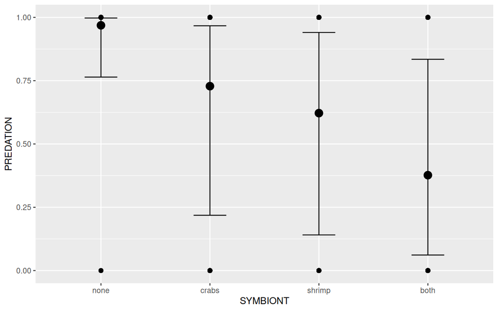

```r
mckeon_brm3 |>
  conditional_effects() |>
  plot(points = TRUE)
```

```
Note: uncertainty of error terms are not taken into account. Consider
  setting `interval` to "prediction". This will call `posterior_predict()`
  instead of `posterior_epred()`.
```

```
Data points may overlap. Use the `jitter` argument to add some amount of
  random variation to the location of data points and avoid overplotting.
```

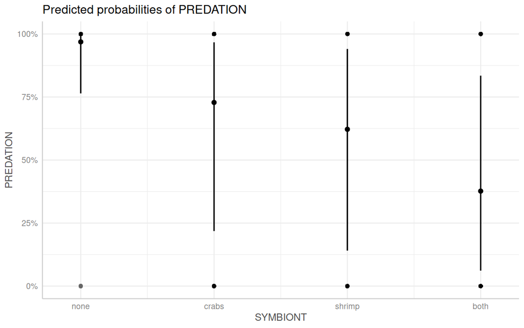

```r
mckeon_brm3 |>
  ggpredict(~SYMBIONT) |>
  plot(show_data = TRUE)
```

```
Data points may overlap. Use the `jitter` argument to add some amount of
  random variation to the location of data points and avoid overplotting.
```

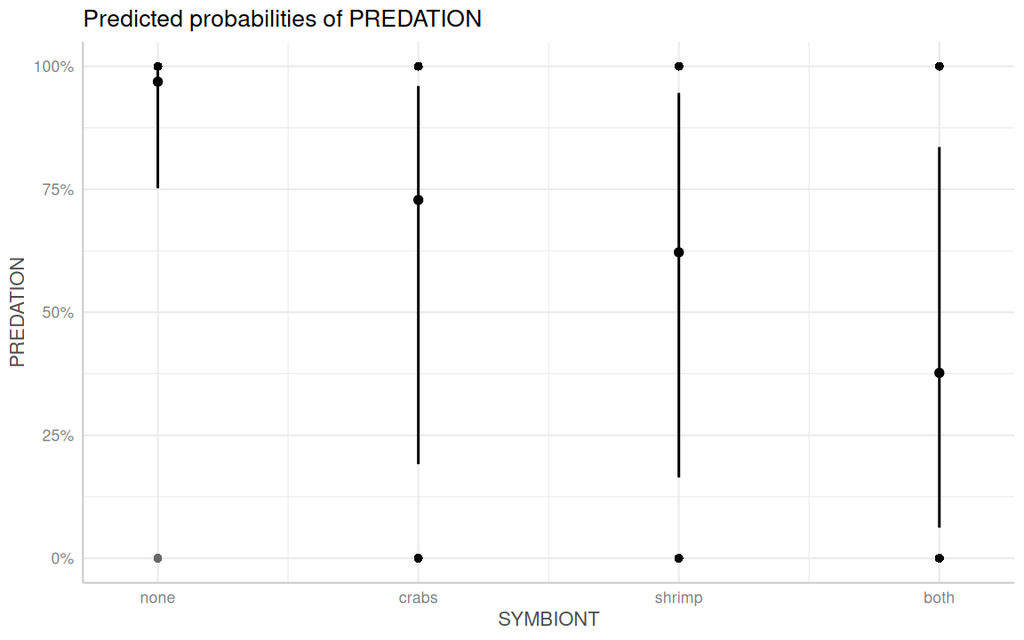

```r
mckeon_brm3 |>
  ggemmeans(~SYMBIONT) |>
  plot(show_data = TRUE)
```

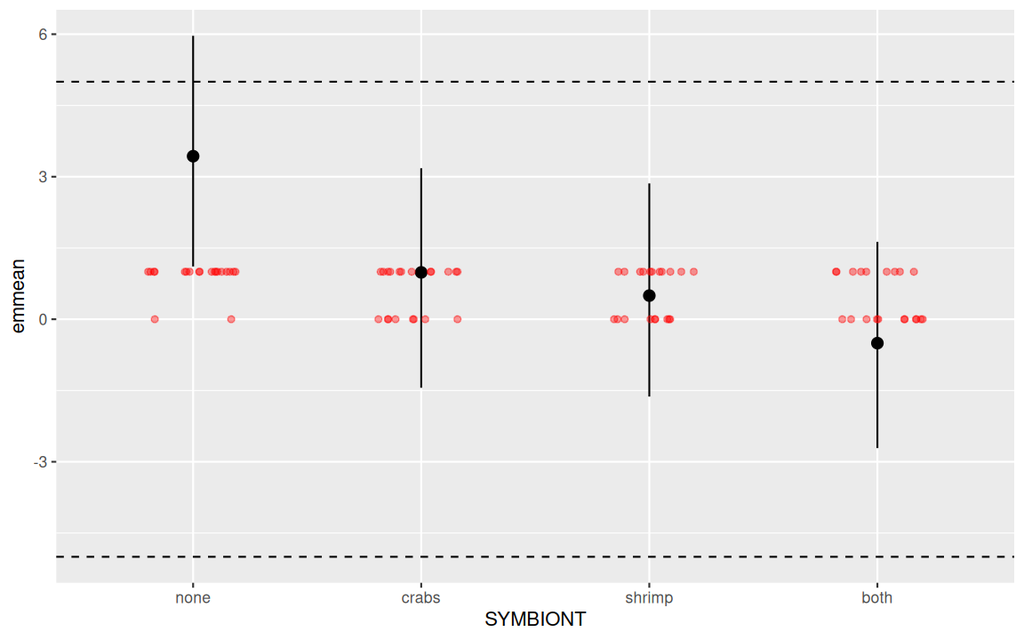

```r
mckeon_brm3 |>
  emmeans(~SYMBIONT, type = "link") |>
  as.data.frame() |>
  ggplot(aes(y = emmean, x = SYMBIONT)) +
  geom_hline(yintercept = c(5, -5), linetype = "dashed") +
  geom_pointrange(aes(ymin = lower.HPD, ymax = upper.HPD)) +
  geom_point(
    data = mckeon, aes(y = PREDATION),
    position = position_jitter(width = 0.2, height = 0),
    alpha = 0.4, color = "red"
  )
```

**Plotting prior and posterior**

```r
mckeon_brm3 |> get_variables()
```

```
 [1] "b_Intercept"           "b_SYMBIONTcrabs"       "b_SYMBIONTshrimp"
 [4] "b_SYMBIONTboth"        "sd_BLOCK__Intercept"   "Intercept"
 [7] "r_BLOCK[1,Intercept]"  "r_BLOCK[2,Intercept]"  "r_BLOCK[3,Intercept]"
[10] "r_BLOCK[4,Intercept]"  "r_BLOCK[5,Intercept]"  "r_BLOCK[6,Intercept]"
[13] "r_BLOCK[7,Intercept]"  "r_BLOCK[8,Intercept]"  "r_BLOCK[9,Intercept]"
[16] "r_BLOCK[10,Intercept]" "prior_Intercept"       "prior_b"
[19] "prior_sd_BLOCK"        "lprior"                "lp__"
[22] "accept_stat__"         "stepsize__"            "treedepth__"
[25] "n_leapfrog__"          "divergent__"           "energy__"
```

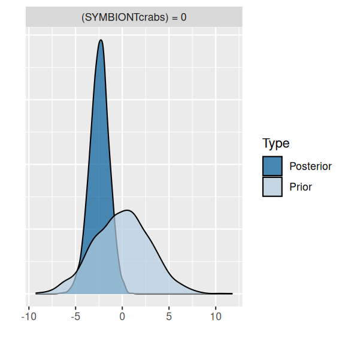

```r
mckeon_brm3 |>
  hypothesis("SYMBIONTcrabs=0") |>
  plot()
```

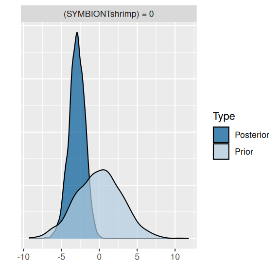

```r
mckeon_brm3 |>
  hypothesis("SYMBIONTshrimp=0") |>
  plot()
```

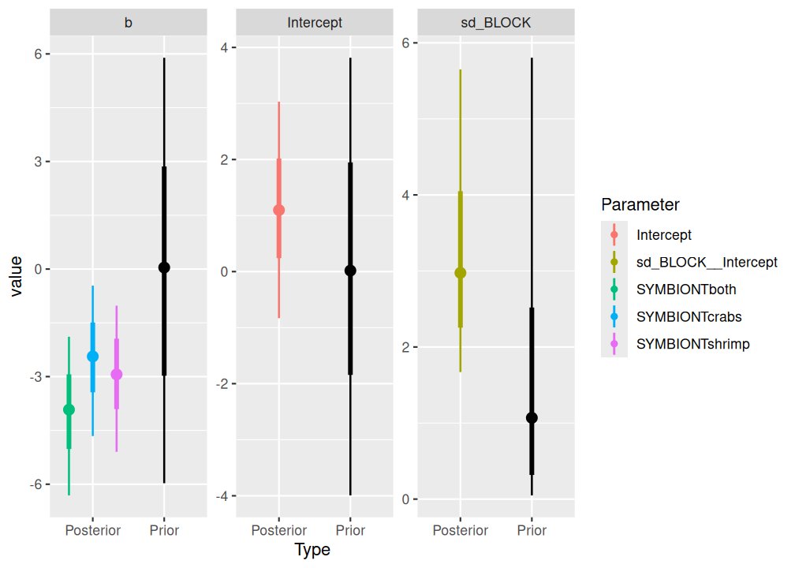

```r
mckeon_brm3 |> SUYR_prior_and_posterior()
```

**Random intercept/slope model**

While we are here, we might like to explore a random intercept/slope model

```r
mckeon_form <- bf(PREDATION | trials(1) ~ SYMBIONT + (SYMBIONT | BLOCK),
  family = binomial(link = "logit")
)
# OR
mckeon_form <- bf(PREDATION ~ SYMBIONT + (SYMBIONT | BLOCK),
  family = bernoulli(link = "logit")
)
get_prior(mckeon_form, mckeon)
```

```
                prior     class           coef group resp dpar nlpar lb ub
               (flat)         b
               (flat)         b   SYMBIONTboth
               (flat)         b  SYMBIONTcrabs
               (flat)         b SYMBIONTshrimp
               lkj(1)       cor
               lkj(1)       cor                BLOCK
 student_t(3, 0, 2.5) Intercept
 student_t(3, 0, 2.5)        sd                                       0
 student_t(3, 0, 2.5)        sd                BLOCK                  0
 student_t(3, 0, 2.5)        sd      Intercept BLOCK                  0
 student_t(3, 0, 2.5)        sd   SYMBIONTboth BLOCK                  0
 student_t(3, 0, 2.5)        sd  SYMBIONTcrabs BLOCK                  0
 student_t(3, 0, 2.5)        sd SYMBIONTshrimp BLOCK                  0
       source
      default
 (vectorized)
 (vectorized)
 (vectorized)
      default
 (vectorized)
      default
      default
 (vectorized)
 (vectorized)
 (vectorized)
 (vectorized)
 (vectorized)
```

```r
## As there are not many observations, the following might be too ambitious without
## stronger priors
priors <-
  prior(normal(0, 2), class = "Intercept") +
  prior(normal(0, 3), class = "b") +
  ## prior(student_t(3,0,1.5), class = 'sd', coef =  "Intercept", group =  "BLOCK") +
  prior(student_t(3, 0, 1.5), class = "sd") +
  prior(lkj_corr_cholesky(1), class = "cor")

mckeon_brm4 <- brm(mckeon_form,
  data = mckeon,
  prior = priors,
  sample_prior = "yes",
  iter = 5000,
  warmup = 1000,
  chains = 3, cores = 3,
  thin = 5,
  refresh = 0,
  control = list(adapt_delta = 0.99, max_treedepth = 20),
  backend = "rstan"
)
```

```r
mckeon_brm4 |> get_variables()
```

```
 [1] "b_Intercept"
 [2] "b_SYMBIONTcrabs"
 [3] "b_SYMBIONTshrimp"
 [4] "b_SYMBIONTboth"
 [5] "sd_BLOCK__Intercept"
 [6] "sd_BLOCK__SYMBIONTcrabs"
 [7] "sd_BLOCK__SYMBIONTshrimp"
 [8] "sd_BLOCK__SYMBIONTboth"
 [9] "cor_BLOCK__Intercept__SYMBIONTcrabs"
[10] "cor_BLOCK__Intercept__SYMBIONTshrimp"
[11] "cor_BLOCK__SYMBIONTcrabs__SYMBIONTshrimp"
[12] "cor_BLOCK__Intercept__SYMBIONTboth"
[13] "cor_BLOCK__SYMBIONTcrabs__SYMBIONTboth"
[14] "cor_BLOCK__SYMBIONTshrimp__SYMBIONTboth"
[15] "Intercept"
```

[output cut: 52 more lines]

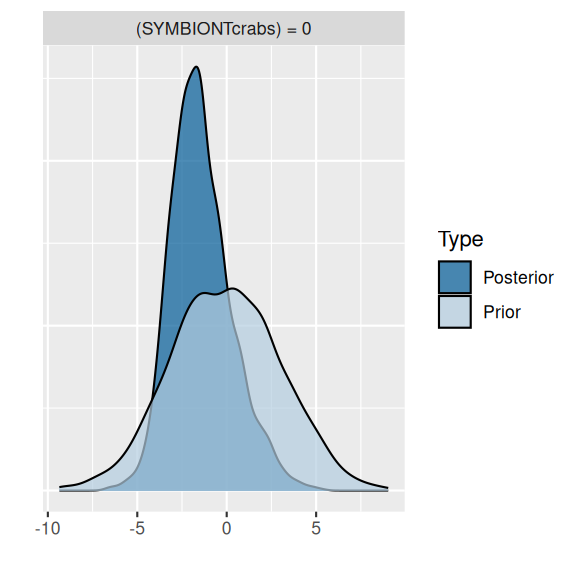

```r
mckeon_brm4 |>
  hypothesis("SYMBIONTcrabs=0") |>
  plot()
```

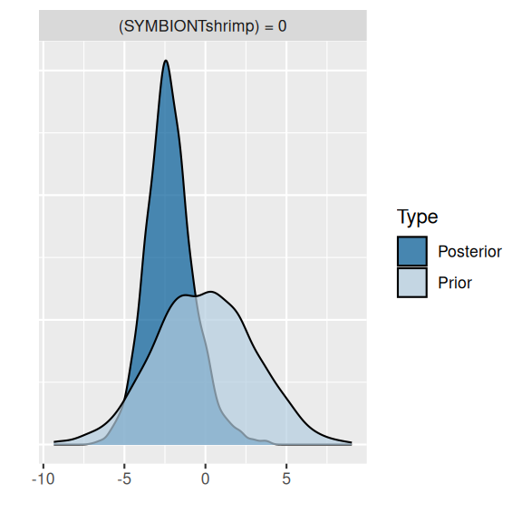

```r
mckeon_brm4 |>
  hypothesis("SYMBIONTshrimp=0") |>
  plot()
```

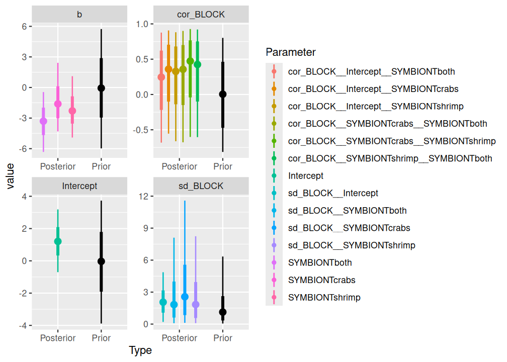

```r
mckeon_brm4 |> SUYR_prior_and_posterior()
```

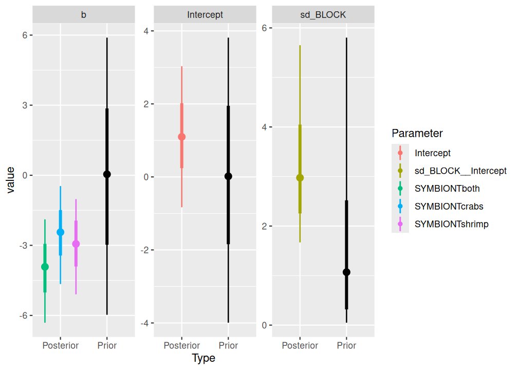

```r
mckeon_brm3 |> SUYR_prior_and_posterior()
```

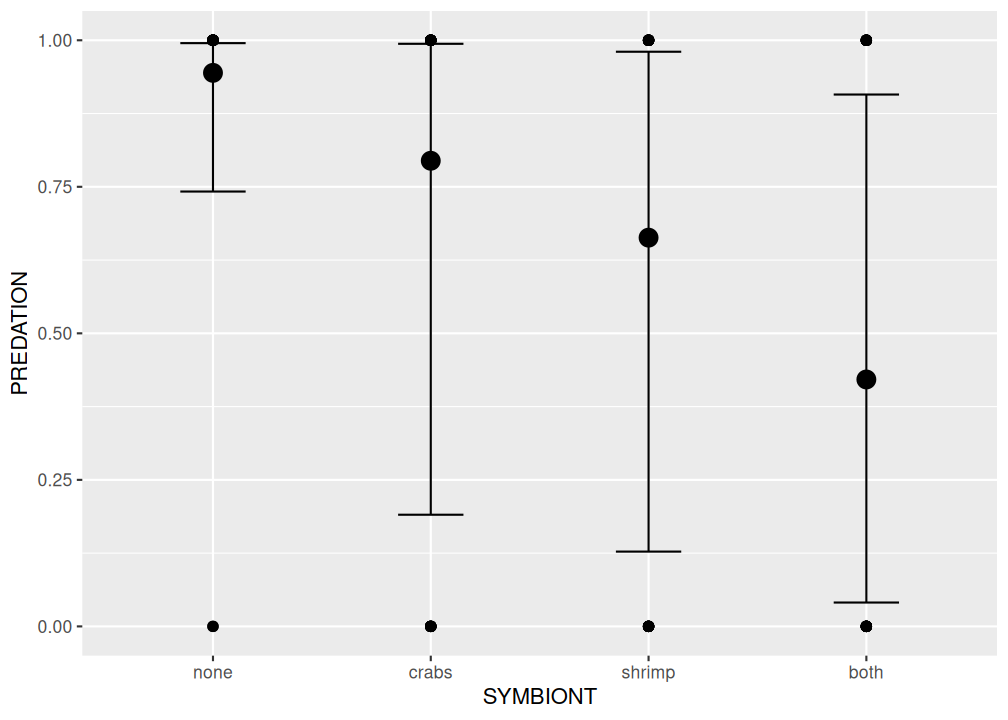

```r
mckeon_brm4 |>
  conditional_effects() |>
  plot(points = TRUE)
```

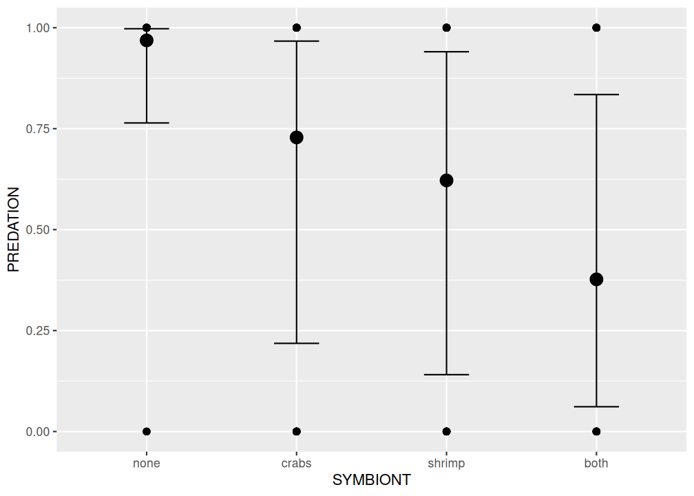

```r
mckeon_brm3 |>
  conditional_effects() |>
  plot(points = TRUE)
```

```r
mckeon_brm4 |> summary()
```

```
 Family: bernoulli
  Links: mu = logit
Formula: PREDATION ~ SYMBIONT + (SYMBIONT | BLOCK)
   Data: mckeon (Number of observations: 80)
  Draws: 3 chains, each with iter = 5000; warmup = 1000; thin = 5;
         total post-warmup draws = 2400

Multilevel Hyperparameters:
~BLOCK (Number of levels: 10)
                                  Estimate Est.Error l-95% CI u-95% CI Rhat
sd(Intercept)                         2.15      1.19     0.20     4.87 1.00
sd(SYMBIONTcrabs)                     3.40      3.47     0.12    11.58 1.00
sd(SYMBIONTshrimp)                    2.39      2.24     0.09     8.24 1.00
sd(SYMBIONTboth)                      2.41      2.33     0.08     8.11 1.00
cor(Intercept,SYMBIONTcrabs)          0.31      0.40    -0.55     0.91 1.00
cor(Intercept,SYMBIONTshrimp)         0.27      0.41    -0.66     0.88 1.00
cor(SYMBIONTcrabs,SYMBIONTshrimp)     0.38      0.41    -0.60     0.93 1.00
cor(Intercept,SYMBIONTboth)           0.21      0.41    -0.68     0.88 1.00
cor(SYMBIONTcrabs,SYMBIONTboth)       0.29      0.42    -0.68     0.90 1.00
cor(SYMBIONTshrimp,SYMBIONTboth)      0.34      0.42    -0.60     0.92 1.00
                                  Bulk_ESS Tail_ESS
sd(Intercept)                         1476     1361
sd(SYMBIONTcrabs)                     1798     2290
sd(SYMBIONTshrimp)                    1756     2160
sd(SYMBIONTboth)                      1905     2208
cor(Intercept,SYMBIONTcrabs)          2144     2222
cor(Intercept,SYMBIONTshrimp)         2146     2089
cor(SYMBIONTcrabs,SYMBIONTshrimp)     2025     2110
cor(Intercept,SYMBIONTboth)           2198     2063
cor(SYMBIONTcrabs,SYMBIONTboth)       1804     2181
cor(SYMBIONTshrimp,SYMBIONTboth)      1606     2235

Regression Coefficients:
               Estimate Est.Error l-95% CI u-95% CI Rhat Bulk_ESS Tail_ESS
Intercept          2.95      1.10     1.06     5.33 1.00     2169     2295
SYMBIONTcrabs     -1.44      1.71    -4.31     2.42 1.00     2167     2133
SYMBIONTshrimp    -2.19      1.49    -4.91     1.11 1.00     1843     2055
SYMBIONTboth      -3.32      1.45    -6.32    -0.45 1.00     1795     2194

Draws were sampled using sampling(NUTS). For each parameter, Bulk_ESS
and Tail_ESS are effective sample size measures, and Rhat is the potential
scale reduction factor on split chains (at convergence, Rhat = 1).
```

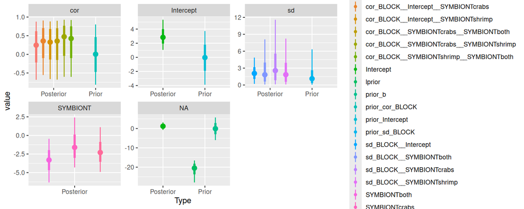

```r
mckeon_brm4 |>
  posterior_samples() |>
  dplyr::select(-`lp__`) |>
  pivot_longer(everything(), names_to = "key") |>
  filter(!str_detect(key, "^r")) |>
  mutate(
    Type = ifelse(str_detect(key, "prior"), "Prior", "Posterior"),
    ## Class = ifelse(str_detect(key, 'Intercept'),  'Intercept',
    ##         ifelse(str_detect(key, 'b'),  'b', 'sigma')),
    Class = case_when(
      str_detect(key, "(^b|^prior).*Intercept$") ~ "Intercept",
      str_detect(key, "b_SYMBIONT.*|prior_b_SYMBIONT.*") &
        !str_detect(key, ".*:.*") ~ "SYMBIONT",
      str_detect(key, "sd") ~ "sd",
      str_detect(key, "^cor|prior_cor") ~ "cor",
      str_detect(key, "sigma") ~ "sigma"
    ),
    Par = str_replace(key, "b_", "")
  ) |>
  ggplot(aes(x = Type, y = value, color = Par)) +
  stat_pointinterval(position = position_dodge()) +
  facet_wrap(~Class, scales = "free")
```

**Compare models**

We can compare the two models using LOO

```r
(l.1 <- mckeon_brm3 |> loo())
```

```
Computed from 2400 by 80 log-likelihood matrix.

         Estimate   SE
elpd_loo    -27.8  6.9
p_loo         8.2  2.5
looic        55.6 13.8
------
MCSE of elpd_loo is 0.1.
MCSE and ESS estimates assume MCMC draws (r_eff in [0.8, 1.1]).

All Pareto k estimates are good (k < 0.7).
See help('pareto-k-diagnostic') for details.
```

```r
(l.2 <- mckeon_brm4 |> loo())
```

```
Computed from 2400 by 80 log-likelihood matrix.

         Estimate   SE
elpd_loo    -25.9  6.1
p_loo        10.3  3.0
looic        51.7 12.2
------
MCSE of elpd_loo is NA.
MCSE and ESS estimates assume MCMC draws (r_eff in [0.7, 1.1]).

Pareto k diagnostic values:
                         Count Pct.    Min. ESS
(-Inf, 0.7]   (good)     77    96.2%   399
   (0.7, 1]   (bad)       3     3.8%   <NA>
   (1, Inf)   (very bad)  0     0.0%   <NA>
See help('pareto-k-diagnostic') for details.
```

```r
loo_compare(l.1, l.2)
```

```
            elpd_diff se_diff
mckeon_brm4  0.0       0.0
mckeon_brm3 -1.9       1.5
```

It appears that the random intercept/slope model is marginally better than the simpler random intercept model.

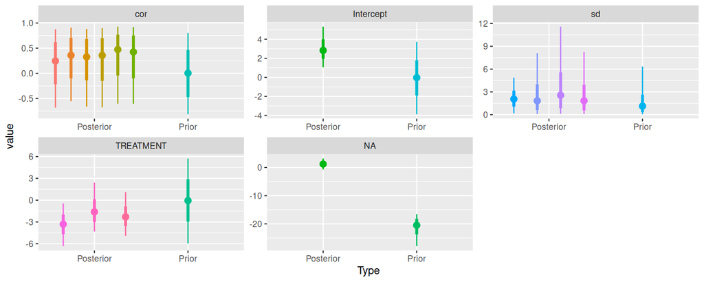

```r
mckeon_brm4 %>%
  posterior_samples() %>%
  dplyr::select(-`lp__`) %>%
  pivot_longer(everything(), names_to = "key") %>%
  filter(!str_detect(key, "^r")) %>%
  mutate(
    Type = ifelse(str_detect(key, "prior"), "Prior", "Posterior"),
    Class = case_when(
      str_detect(key, "(^b|^prior).*Intercept$") ~ "Intercept",
      str_detect(key, "b_SYMBIONT.*|prior_b") ~ "TREATMENT",
      str_detect(key, "sd") ~ "sd",
      str_detect(key, "^cor|prior_cor") ~ "cor",
      str_detect(key, "sigma") ~ "sigma"
    ),
    Par = str_replace(key, "b_", "")
  ) %>%
  ggplot(aes(x = Type, y = value, color = Par)) +
  stat_pointinterval(position = position_dodge(), show.legend = FALSE) +
  facet_wrap(~Class, scales = "free")
```